# Projet_R_Graph

Benjamin Munoz

25 janvier, 2022

## Module Graphe

Ce projet a pour but la description des liens évolutifs au sein de groupes de virus de procaryotes.Pour cela, les contenus en gènes (ou plus précisément en groupes d’orthologues) des virus serontcomparés et ces résultats permettront de modéliser les relations entre virus sous la forme dedifférents réseaux.

## Partie 1

### Réunir les segments de virus en un seul virus

I.1 Il faut tout d’abord réunir les différents segments des virus segmentés en une seule ligne par virus (leur génome sont en plusieurs morceaux et chaque morceau est une ligne du fichier.tsv) Il n’y en a qu’une poignée, toutes les autres lignes correspondent à des virus uniques (certains virus ont le même nom mais qui représentent bien des souches ou isolats différents)

```r
paste(data_path, "refPhages_and_VirSorter.tsv", sep = "") -> virus_list_path


read_tsv(virus_list_path) -> ListeVirus
#dim(ListeVirus)

SegmentVirusRegroupe <-
  ListeVirus %>%
    filter(grepl("segment", Definition)) %>%
    arrange(Name) %>%
    group_by(Name) %>%
    mutate(
      gc=mean(GC),
      length=sum(Length),
      nb_Prot=sum(nb_prot),
      nb_phROGs=sum(nb_PhROGs),
      nb_sing=sum(nb_Sing),
      nb_paralog=sum(nb_Paralog)
    ) %>%
    distinct(Name, .keep_all = TRUE) %>%
    select(
      -GC,
      -Length,
      -nb_prot,
      -nb_PhROGs,
      -nb_Sing,
      -nb_Paralog
    ) %>%
    rename(
      GC=gc,
      Length=length,
      nb_prot=nb_Prot,
      nb_PhROGs=nb_phROGs,
      nb_Sing=nb_sing,
      nb_Paralog=nb_paralog
    )

ListeVirus <- ListeVirus %>%
  filter(!grepl("segment", Definition)) %>%
  bind_rows(SegmentVirusRegroupe)
```

### Filtrer les problèmes de prédiction

I.2 Filtrer les virus pour lesquels il y a visiblement eu un problème de prédiction de protéine(normalement, il y a un peu plus de 1 gène codant une protéine pour 1000 pb, s’il y a moins de 1 gène pour 10 000 pb c’est qu’il y a un problème)

```r
ListeVirus <- ListeVirus %>%
  filter(Length/nb_prot < 10000)
```

### Visualisation des génomes par genre

I.3 Pour les virus infectant les genres suivants : Synechococcus, Clostridium, Streptomyces, Lactococcus, Neisseria, Enterococcus, : • déterminer le nombre de virus les infectant • faire des boxplot pour la taille des génomes et le GC % pour chaque groupe (un graphique pour les tailles de génomes, un pour le GC %, une couleur différentes par genre)

#### Nombre d’infections par genre

```r
NbInfectionsParGenre <-
  ListeVirus %>%
    select(Name, genus) %>%
    filter(genus %in% c(
      "Clostridium",
      "Synechococcus",
      "Lactococcus",
      "Neisseria",
      "Enterococcus",
      "Streptomyces")
    ) %>%
    distinct(Name, .keep_all = T) %>%
    count(genus) %>%
    rename(nb_virus=n)

TotalVirus <-
  select(NbInfectionsParGenre, nb_virus) %>%
    colSums()
```

#### Taille des génomes par genre

```r
Clostridium <- virusParGenre(ListeVirus, "Clostridium")
Synechococcus <- virusParGenre(ListeVirus, "Synechococcus")
Lactococcus <- virusParGenre(ListeVirus, "Lactococcus")
Neisseria <- virusParGenre(ListeVirus, "Neisseria")
Enterococcus <- virusParGenre(ListeVirus, "Enterococcus")
Streptomyces <- virusParGenre(ListeVirus, "Streptomyces")
```

#### Taille des génomes : boite de Tukey (boxplot)

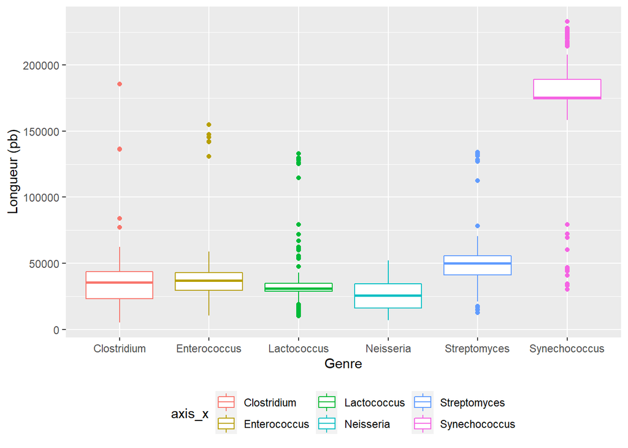

```r
generateBoxPlot <- function(
    data_array,
    axis_x,
    axis_y,
    legend_x,
    legend_y,
    title,
    caption=""
  ) {
  data_array %>%
    ggplot(aes(axis_x, axis_y, color=axis_x)) +
    geom_boxplot() +
    xlab(legend_x) +
    ylab(legend_y) +
    labs(title, caption) +
    theme(
        legend.position = "bottom",
        plot.title = element_text(hjust = 0.5)
      )
  #/data_array
}



generateBoxPlot(
  ListeVirusFilterGenre,
  (ListeVirusFilterGenre$genus),
  (ListeVirusFilterGenre$Length),
  "Genre",
  "Longueur (pb)",
  "longueur des génomes viral en pb"
)
```

#### Pourcentage de GC : boite de Tukey (boxplot)

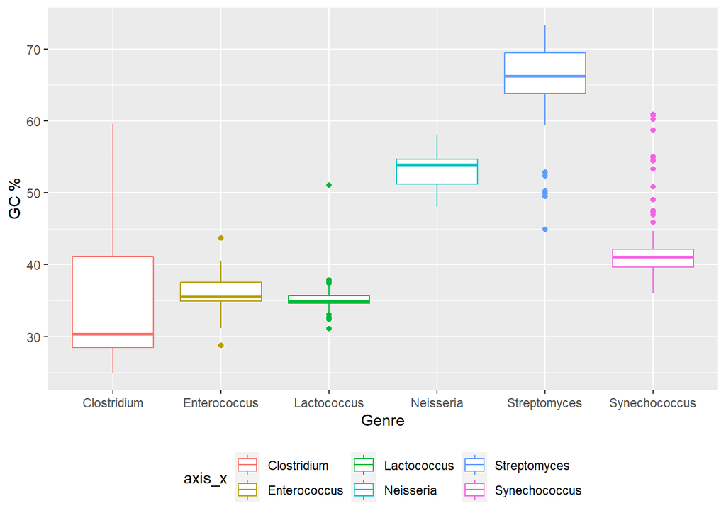

```r
generateBoxPlot(
  ListeVirusFilterGenre,
  (ListeVirusFilterGenre$genus),
  (ListeVirusFilterGenre$GC),
  "Genre",
  "GC %",
  "GC % pour chaque groupe"
)
```

Le boxplot ici présent, nous montre le pourcentage de GC en fonction des groupes de virus infectant les six genres de bactéries où le pourcentage le plus élevé est pour Streptomyces au alentours de 65% en GC des génomes des bactériophages.

### Distribution de la conservation des groupes d’orthologues

I.4 Pour chaque groupe de virus de la question précédente, faire une distribution de la conservation des groupes d’orthologues au sein du groupe (déterminer la liste des groupes d’orthologues du groupe puis leur conservation dans le groupe avec Python), puis faire deux graphiques avec R: •les 6 histogrammes (coloriés selon les mêmes couleurs que définies précédemment)sur une grille de 2 lignes et de 3 colonnes •les 6 distributions sous la forme de courbes (mêmes couleurs) sur un mêmegraphique

#### Filtrer par groupe de genre

On va dabord filtrer les éléments qui nous interesse, puis l’extraire sous forme de fichier tsv exploitable par un futur script python.

```r
ListeVirus %>%
  filter(genus %in% c("Clostridium", "Synechococcus", "Lactococcus", "Neisseria", "Enterococcus", "Streptomyces")) %>%
  distinct(Locus, .keep_all = TRUE) -> Genre_Infect

write_tsv(Genre_Infect, "C:/Users/benja/Projet-Relation-Virus/results/Genre_Infect.tsv")
```

#### Script python générant un fichier pour la distribution de la conservation des groupes orthologues

```python
from collections import defaultdict
from math import sqrt
import re
import os.path

pathGenreInfect = "C:/Users/benja/Projet-Relation-Virus/results/Genre_Infect.tsv"
pathProteins = "C:/Users/benja/Projet-Relation-Virus/data/virSorter_proteins_entete.faa"
pathList = "C:/Users/benja/Projet-Relation-Virus/data/phrogs_list"
dirConservation = "C:/Users/benja/Projet-Relation-Virus/results/Conservation_grp_ortho.tsv"

dictGenreNomLocus=defaultdict(list)
i=0
with open(pathGenreInfect,"r") as f3:
    for li in f3:
        if not li.startswith("Locus"):
            li=li.rstrip("\n")
            lp=li.split("\t")
            dictGenreNomLocus[lp[-4]].append(lp[0]) #Genre avec les noms de locus
            i+=1


dictProteinesNomVirus=defaultdict(str)
with open(pathProteins, "r") as f2:
    for li in f2:
        li=li.rstrip("\n")
        lp=li.split()
        nomVirus=lp[1]
        proteine=lp[0].lstrip(">")
        dictProteinesNomVirus[proteine]=nomVirus #clef sont les protéines et en valeur l'id de virus associé à la protéine



dictNumeroGrpOrthoNomVirus=defaultdict(set)
i=0
with open(pathList,"r") as f1:
    for li in f1:
        li=li.rstrip("\n")
        i+=1
        lp=li.split()
        for virus in lp:
            match=re.search("_p\d+$",virus) #recherche des protéines finissant par _pEEEE
            if match:
                virus=virus.rstrip(match.group()) #si c'est une protéine finissant par _pEEEE, on enleve cette partie de l'identifiant et on ajoute au dictionnaire
                dictNumeroGrpOrthoNomVirus["phrogs_"+str(i)].add(virus)
            else:
                dictNumeroGrpOrthoNomVirus["phrogs_"+str(i)].add(dictProteinesNomVirus[virus]) #sinon on va chercher dans le dictionnaire créé avant le nom de virus associé à la protéine (VirSorter)


dictGenreNumGrpOrthoApparition=defaultdict(lambda:defaultdict(int))
for genre in dictGenreNomLocus:
    for nomLocus in dictGenreNomLocus[genre]:
        for numeroGrpOrtho in dictNumeroGrpOrthoNomVirus:
            if nomLocus in dictNumeroGrpOrthoNomVirus[numeroGrpOrtho]:
                dictGenreNumGrpOrthoApparition[genre][numeroGrpOrtho]+=1


i=0
for genre in dictGenreNumGrpOrthoApparition:
    for numeroGrpOrtho in dictGenreNumGrpOrthoApparition[genre]:
         if i:
            with open(dirConservation,"a") as fichier:
                fichier.write(genre + "\t" + numeroGrpOrtho + "\t" + str(dictGenreNumGrpOrthoApparition[genre][numeroGrpOrtho]/len(dictGenreNomLocus[genre])) + "\n")
         else:
            i+=1
            with open(dirConservation,"w") as fichier:
                fichier.write("Genre\tPhrogs\tConservation\n")
```

#### Représentation graphique de la conservation des groupes orthologues

Lecture du fichier créer via un script python

```r
path_results = "C:/Users/benja/Projet-Relation-Virus/results/"

paste(path_results, "Conservation_grp_ortho.tsv", sep = "") -> ConservationOrtho_path

read_tsv(file = ConservationOrtho_path) -> ConservationOrtho

#Changement des valeurs de conservation en % (pour des questions de lisibilité)
ConservationOrtho %>%
  mutate(conservation=Conservation*100) %>%
  select(-Conservation) -> ConservationOrtho2
```

#### histograme de la conservation des groupes orthologues en facet_wrap

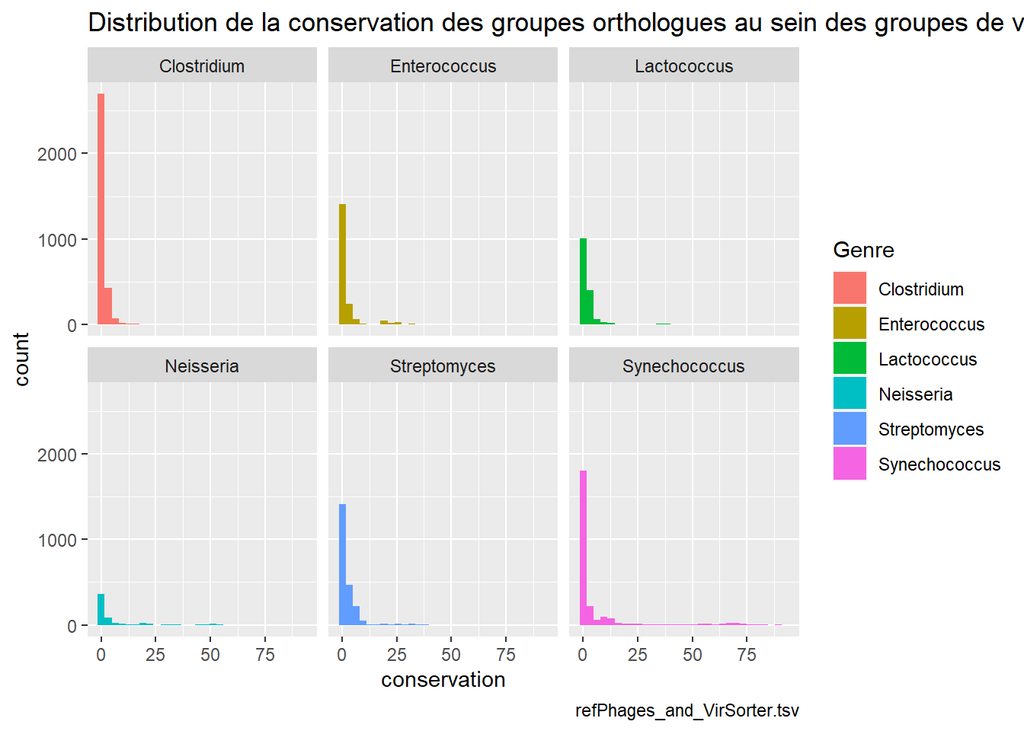

```r
ConservationOrtho2 %>%
  ggplot(aes(conservation)) +
  geom_histogram(aes(fill=Genre)) +
  labs(caption = "refPhages_and_VirSorter.tsv",
       title="Distribution de la conservation des groupes orthologues au sein des groupes de virus") +
  theme(plot.title = element_text(hjust = 0)) +
  facet_wrap(~Genre, nrow = 2)
```

On observe que globalement, tous les groupes orthologue ont une faible conservation, proche de zero.

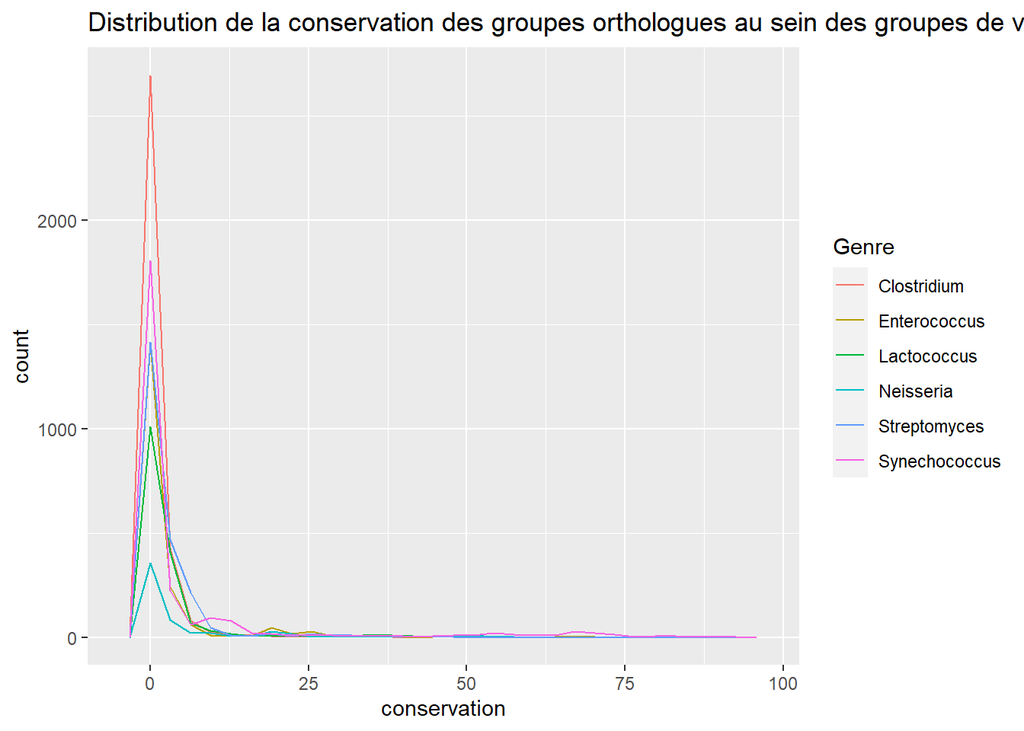

```r
ConservationOrtho2 %>%
  ggplot(aes(conservation, colour=Genre)) +
  geom_freqpoly()+
  labs(title= "Distribution de la conservation des groupes orthologues au sein des groupes de virus") +
  theme(plot.title = element_text(hjust = 0))
```

Même chose que précédement, mais ici on s’aperçoit mieux du chevauchement autour de zero de la distribution des groupes orthologue, dont Clostridium contient la plus haute valeur (sur l’axe verticale) proche de zero.

Remarque : le pourcentage devrait commencer à zero, alors que dans ce graphique, tous les groupes commencent un peu avant zero, si l’on regarde bien, un ajustement est peut-être necessaire pour réctifier cette marge.

## Partie 2

II.1 Pour votre groupe de virus, déterminer la liste des groupes d’orthologues présents et pour chaque couple de virus du groupe, compter le nombre de groupes d’orthologues présents dans les 2 virus (peu importe le nombre de protéines de chaque virus présents dans chaque groupe d’orthologue, par exemple si le groupe d’orthologue 12 compte 2 protéines du virus1 et 3 protéines du virus2 (donc des paralogues), on comptera que ces deux virus ont 1 groupe d’orthologue en commun).

```r
ListeVirus %>%
  filter(family %in% c("Sutterellaceae", "Oxalobacteraceae", "Comamonadaceae", "Alcaligenaceae")) -> Grp_virus

write_tsv(Grp_virus, "C:/Users/benja/Projet-Relation-Virus/results/Grp_virus.tsv")
```

#### Script python générant un fichier

```python
from collections import defaultdict
from math import sqrt
import re



list_ortho = "C:/Users/benja/Projet-Relation-Virus/data/phrogs_list"
prot_virus = "C:/Users/benja/Projet-Relation-Virus/data/virSorter_proteins_entete.faa"
Grp_virus = "C:/Users/benja/Projet-Relation-Virus/results/Grp_virus.tsv"
Grp_ortho = "C:/Users/benja/Projet-Relation-Virus/results/repartition_grps_orthologues.tsv"

dict_idProt_ortho=defaultdict(str)
dict_idVirus_setOrtho=defaultdict(set)
dict_idProt_idVirus=defaultdict(str)


with open(list_ortho, "r") as f1 :
    compt=0
    for li in f1 :
        li=li.rstrip("\n")
        ls=li.split()
        compt+=1
        ortho="Ortho"+str(compt)
        ortho = compt   # numéro de ligne du groupe orthologue

        for prot in ls :

            if prot.startswith("p") :
                dict_idProt_ortho[prot]=ortho
                # print(prot)
            else :
                id_virus = re.sub("_p\d+","",prot)
                #print(prot, id_virus)
                dict_idVirus_setOrtho[id_virus].add(ortho)


with open(prot_virus, "r") as f2 :
    for li in f2 :
        li = li.rstrip("\n")
        li = li.lstrip(">")
        ls = li.split()
        id_prot = ls[0]
        id_virus= ls[1]
        dict_idProt_idVirus[id_prot] = id_virus

for idProt in dict_idProt_ortho :
    ortho = dict_idProt_ortho[idProt]
    id_virus = dict_idProt_idVirus[idProt]
    dict_idVirus_setOrtho[id_virus].add(ortho)



dict_GroupeIdVirus_ortho = defaultdict(list)
dict_virus1_virus2_nbOrthoCommun = defaultdict(lambda : defaultdict(int))

with open(Grp_virus, "r") as f3 :
        for li in f3 :
            li=li.rstrip("\n")
            ls=li.split("\t")
            idVirus=ls[0]
            ortho = list(dict_idVirus_setOrtho[idVirus])
            dict_GroupeIdVirus_ortho[idVirus]=ortho

listDejaVue=[]

for virus1 in dict_GroupeIdVirus_ortho :
    listDejaVue.append(virus1)
    for virus2 in dict_GroupeIdVirus_ortho :
        if virus2 not in listDejaVue :
            for ortho1 in dict_GroupeIdVirus_ortho[virus1] :
                if ortho1 in dict_GroupeIdVirus_ortho[virus2] :
                    dict_virus1_virus2_nbOrthoCommun[virus1][virus2]+=1


repartition_grps_orthologues=open(Grp_ortho,'w')
repartition_grps_orthologues.write("virus1"+"\t"+"virus2"+"\t"+ "nb_commun" +"\n" )
for virus1 in dict_virus1_virus2_nbOrthoCommun :
        for virus2 in dict_virus1_virus2_nbOrthoCommun[virus1] :
            nb_commun=dict_virus1_virus2_nbOrthoCommun[virus1][virus2]
            repartition_grps_orthologues.write(virus1+"\t"+virus2+"\t"+ str(nb_commun)+"\n" )

repartition_grps_orthologues.close()
```

### Partie Igraph

#### Calcul des indices (caractéristiques du réseau)

```r
paste(path_results,"repartition_grps_orthologues.tsv", sep = "") -> residGraph_path

read_tsv(file = residGraph_path) -> residGraph

graph_from_data_frame(residGraph, directed = F) -> residGraph2
```

Le graph est donc non dirigé (U), nommé(N) mais pas pondéré(W)

II.2.1

```r
#nombre de liens (arètes)
E(residGraph2)
```

```
## + 1152/1152 edges from e5899f9 (vertex names):
##  [1] NC_013697--MF663786  NC_013697--NC_029075 NC_013697--NC_027348
##  [4] NC_013697--KF787094  NC_013697--NC_028908 NC_013697--NC_023556
##  [7] NC_013697--VI_01096  NC_013697--NC_029106 NC_013697--KY000219
## [10] NC_013697--KY000220  NC_013697--KY000218  NC_013697--KX961385
## [13] NC_013697--KY000221  NC_013697--VI_01114  NC_013697--VI_01077
## [16] NC_013697--VI_01098  NC_013697--NC_028768 NC_013697--NC_028834
## [19] NC_013697--VI_05578  NC_013697--NC_029033 NC_013697--VI_05545
## [22] NC_013697--NC_005357 NC_013697--VI_01111  NC_013697--VI_01081
## [25] NC_013697--VI_05726  NC_013697--NC_028702 NC_013697--VI_01115
## [28] NC_013697--VI_05579  NC_013697--NC_029061 NC_013697--VI_01069
## + ... omitted several edges
```

```r
Poids_Liens <- E(residGraph2)$nb_commun
nbLiens = 1152

#pour que mon graph soit pondéré
residGraph$nb_commun -> E(residGraph2)$weight
#E(residGraph2)$weight
residGraph2
```

```
## IGRAPH e5899f9 UNW- 70 1152 --
## + attr: name (v/c), nb_commun (e/n), weight (e/n)
## + edges from e5899f9 (vertex names):
##  [1] NC_013697--MF663786  NC_013697--NC_029075 NC_013697--NC_027348
##  [4] NC_013697--KF787094  NC_013697--NC_028908 NC_013697--NC_023556
##  [7] NC_013697--VI_01096  NC_013697--NC_029106 NC_013697--KY000219
## [10] NC_013697--KY000220  NC_013697--KY000218  NC_013697--KX961385
## [13] NC_013697--KY000221  NC_013697--VI_01114  NC_013697--VI_01077
## [16] NC_013697--VI_01098  NC_013697--NC_028768 NC_013697--NC_028834
## [19] NC_013697--VI_05578  NC_013697--NC_029033 NC_013697--VI_05545
## [22] NC_013697--NC_005357 NC_013697--VI_01111  NC_013697--VI_01081
## + ... omitted several edges
```

```r
#nombre de noeuds (de virus)
V(residGraph2)
```

```
## + 70/70 vertices, named, from e5899f9:
##  [1] NC_013697 MF663786  NC_029075 NC_027348 KF787094  NC_028908 NC_023556
##  [8] VI_01096  VI_05604  NC_029106 KY000219  KY000220  KY000218  KX961385
## [15] KY000221  VI_01114  VI_01077  VI_01098  NC_028768 NC_028834 VI_05578
## [22] NC_029033 VI_05545  NC_005357 VI_01099  VI_01106  VI_01111  VI_01093
## [29] VI_01081  VI_05726  NC_028702 VI_01115  VI_05579  NC_029061 VI_01069
## [36] VI_05731  VI_05733  VI_05582  VI_01082  VI_05620  VI_05548  VI_05605
## [43] VI_01071  VI_05580  VI_05588  VI_01073  VI_01117  VI_05734  VI_01100
## [50] VI_01076  VI_01092  VI_01097  VI_05590  VI_01080  VI_05589  VI_05737
## [57] VI_01116  VI_01118  VI_05729  VI_01072  VI_05735  VI_05727  VI_05730
## [64] VI_01107  VI_05581  VI_05603  VI_05736  VI_05732  VI_05728  VI_05546
```

```r
V(residGraph2)$name
```

```
##  [1] "NC_013697" "MF663786"  "NC_029075" "NC_027348" "KF787094"  "NC_028908"
##  [7] "NC_023556" "VI_01096"  "VI_05604"  "NC_029106" "KY000219"  "KY000220"
## [13] "KY000218"  "KX961385"  "KY000221"  "VI_01114"  "VI_01077"  "VI_01098"
## [19] "NC_028768" "NC_028834" "VI_05578"  "NC_029033" "VI_05545"  "NC_005357"
## [25] "VI_01099"  "VI_01106"  "VI_01111"  "VI_01093"  "VI_01081"  "VI_05726"
## [31] "NC_028702" "VI_01115"  "VI_05579"  "NC_029061" "VI_01069"  "VI_05731"
## [37] "VI_05733"  "VI_05582"  "VI_01082"  "VI_05620"  "VI_05548"  "VI_05605"
## [43] "VI_01071"  "VI_05580"  "VI_05588"  "VI_01073"  "VI_01117"  "VI_05734"
## [49] "VI_01100"  "VI_01076"  "VI_01092"  "VI_01097"  "VI_05590"  "VI_01080"
## [55] "VI_05589"  "VI_05737"  "VI_01116"  "VI_01118"  "VI_05729"  "VI_01072"
## [61] "VI_05735"  "VI_05727"  "VI_05730"  "VI_01107"  "VI_05581"  "VI_05603"
## [67] "VI_05736"  "VI_05732"  "VI_05728"  "VI_05546"
```

```r
nbSommets = 70
```

```r
#nbre de liens possibles
nbLpossibles = nbSommets*(nbSommets+1)/2
nbLpossibles
```

```
## [1] 2485
```

II.2.2

```r
##parametre gamma : nbre de liens/nbre de liens possibles
Gamma=nbLiens/nbLpossibles
Gamma
```

```
## [1] 0.4635815
```

```r
#edge_density(residGraph2)
```

La valeur gamma retenu étant de 0.46, on a un réseau moyennement connecté

II.2.3

```r
# le diametre = on cherche le plus court chemin pour rejoindre le voisin le plus éloigné
diameter(residGraph2, directed = F)
```

```
## [1] 6
```

```r
#print_all(residGraph2)
```

Le diamètre du réseau, qui correspond au plus court chemin entre deux sommets les plus éloignés est ici de 6

II.2.4

```r
# le parametre Eta : Longueur moyenne des arcs
mean_distance(residGraph2)
```

```
## [1] 1.643064
```

II.2.5

```r
# Transitivité (coefficient de clustering)
transitivity(residGraph2, type = "global")
```

```
## [1] 0.7340767
```

```r
transitivity(residGraph2, type = "local")
```

```
##  [1] 0.6928770 0.7155050 0.7076613 0.7907692 0.7399194 0.7692308 0.7399194
##  [8] 0.6380154 0.6444444 0.7733333 0.7409806 0.7409806 0.7409806 0.7409806
## [15] 0.7409806 0.7536946 0.7171717 0.6693878 0.7261795 0.7261795 0.7016129
## [22] 0.6955782 0.6394130 0.7400555 0.6733871 0.5760743 0.7519380 0.7130125
## [29] 0.7020408 0.6235690 0.6809524 0.7012411 0.7440860 0.7862950 0.8333333
## [36] 0.7404040 0.7318548 0.6921182 0.8191633 0.6989796 0.6914286 0.8091954
## [43] 0.9378151 0.8682540 0.6985294 0.7400000 0.6857143 0.7333333 0.8634921
## [50] 0.5573123 1.0000000 0.8545455 0.7320261 1.0000000 0.8616601 0.8534851
## [57] 0.8300000 1.0000000 0.7282828 0.6952381 0.8421053 0.8421053 0.8421053
## [64] 1.0000000 1.0000000 1.0000000 0.9642857 1.0000000 0.8268398 1.0000000
```

Ce coeficient mesure la probabilité que des sommets soient connectés, avec ici pour un coeficient d’aglomération global qui est une moyenne de l’ensembles des valeurs local, égal à 0.73, soit proche de 1, donc une aglomération global relativement importante

II.2.6

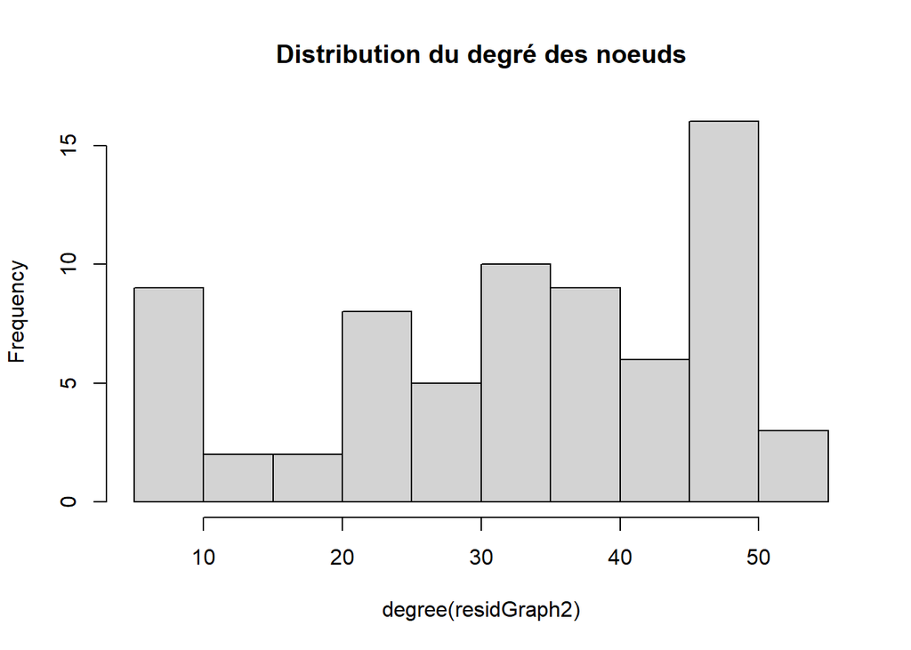

```r
# histogramme du degré des noeuds (le nombres d'arètes qui passent par un noeud)
hist(degree(residGraph2),
     main = "Distribution du degré des noeuds")
```

#### Ajustement

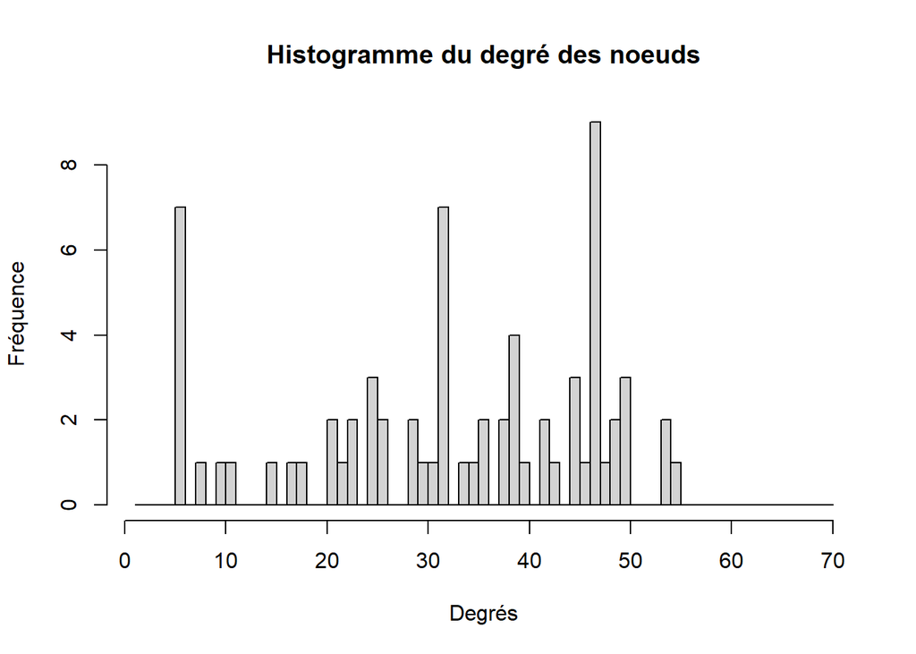

```r
#Pour plus de précision
degre <- degree(residGraph2)
hist(degre,
     breaks = 1:vcount(residGraph2),
     main= "Histogramme du degré des noeuds",
     xlab= "Degrés",
     ylab = "Fréquence")
```

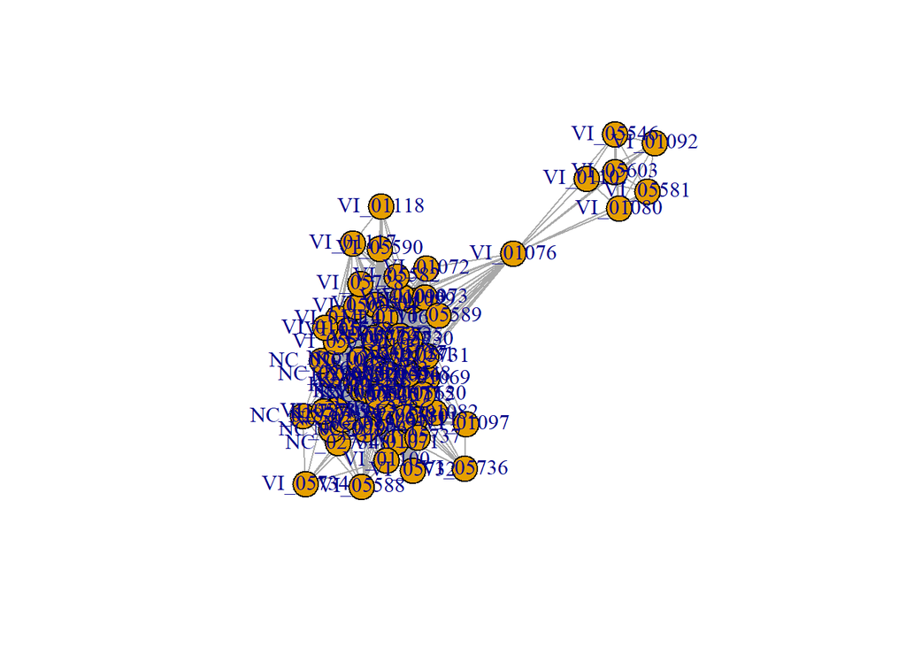

```r
#le réseau
plot(residGraph2, directed = F)
```

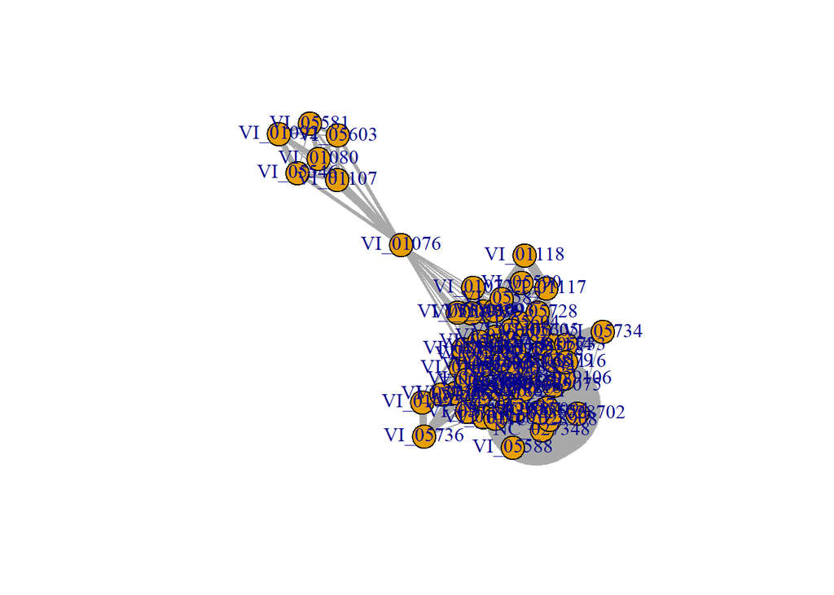

```r
#même chose en considérant le poids des liens
plot(residGraph2, edge.width= Poids_Liens, directed = F)
```

```r
summary(residGraph2)
```

```
## IGRAPH e5899f9 UNW- 70 1152 --
## + attr: name (v/c), nb_commun (e/n), weight (e/n)
```

#### Edition : Modifier le réseau

##### centralité intermédiaire avec un layout (directed force)

II.2.7 dessiner le graphe en directed force en colorant les nœuds en fonction de leur centralité d’intermédiarité (betweeness)

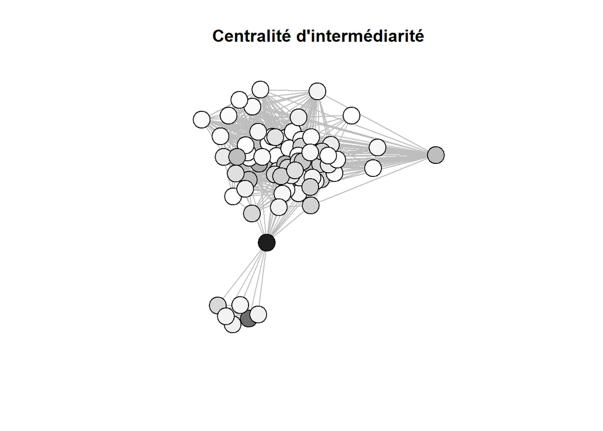

```r
l <- layout_with_fr(residGraph2,
                           dim=2,
                           weights = E(residGraph2))
btw <- betweenness(residGraph2,
                   directed = FALSE)
fine = 500
pal = colorRampPalette(c('white', 'gray33', 'black'))
graphCol = pal(fine)[as.numeric(btw,breaks = fine)]

set.seed(1)
plot(residGraph2,
     layout=l,
     edge.color="grey",
     #edge.width=Poids_Liens,
     vertex.color=graphCol,
     vertex.label=NA,
     main ="Centralité d'intermédiarité")
```

```r
#hist(betweenness(residGraph2))
```

Comme on peut le voir à travers ce graphique, plus la couleur tend vers le foncé (noir) plus la centralité d’intermédiare pour ce noeud aura de l’importance, on constate que le noeud dont la centralité est la plus importante est le noeud noir qui relie deux composante du graphe. Ce qui est en cohérence avec la définition de betweenness, donc le script fonctionne comme prévu.

##### centralité intermédiaire + layout() + noeuds(prophages=carré, sinon=cercle, undef=triangle)

II.2.8 dessiner le graphe en utilisant la même disposition des nœuds et les mêmes couleurs que précédemment et en dessinant les nœuds correspondant à des prophages en carré, en cercle sinon (et en triangle pour « undef »)

R ne connaissant pas les triangles, une fonction qui code une forme de triangle est disponible sur internet (github) ou bien directement de l’interface help de RStudio

```r
mytriangle <- function(coords, v=NULL, params) {
  vertex.color <- params("vertex", "color")
  if (length(vertex.color) != 1 && !is.null(v)) {
    vertex.color <- vertex.color[v]
  }
  vertex.size <- 1/200 * params("vertex", "size")
  if (length(vertex.size) != 1 && !is.null(v)) {
    vertex.size <- vertex.size[v]
  }

  symbols(x=coords[,1], y=coords[,2], bg=vertex.color,
          stars=cbind(vertex.size, vertex.size, vertex.size),
          add=TRUE, inches=FALSE)
}
add_shape("triangle", clip=shapes("circle")$clip,
                 plot=mytriangle)
```

##### distinction entre les prophages, non prophage et undef

[figure not shown]

```r
V(residGraph2)$prophage <- as.character(Grp_virus$prophage[match(V(residGraph2)$name,Grp_virus$Locus)])
V(residGraph2)[V(residGraph2)$prophage=="undef"]$shape <- "triangle"
V(residGraph2)[V(residGraph2)$prophage=="yes"]$shape <- "square"
V(residGraph2)[V(residGraph2)$prophage=="no"]$shape <- "circle"

set.seed(1)
{plot(residGraph2,
     layout=l,
     edge.color="grey",
     #edge.width=Poids_Liens,
     vertex.color=graphCol,
     vertex.label="",
     vertex.shapes=V(residGraph2)$shape,
     main = "Centralité d'intermédiarité")
legend("topleft", legend=c("prophage","non prophage","undef"), pch=c(1,0,2), bty="n")}
```

##### centralisation par le degré des noeuds (degree) et de proximité (closeness)

II.2.9 dessiner le graphe en utilisant la même disposition des nœuds que précédemment et les mêmes formes et en colorant les nœuds en fonction de la centralité de degré puis la centralisation de proximité (closeness)

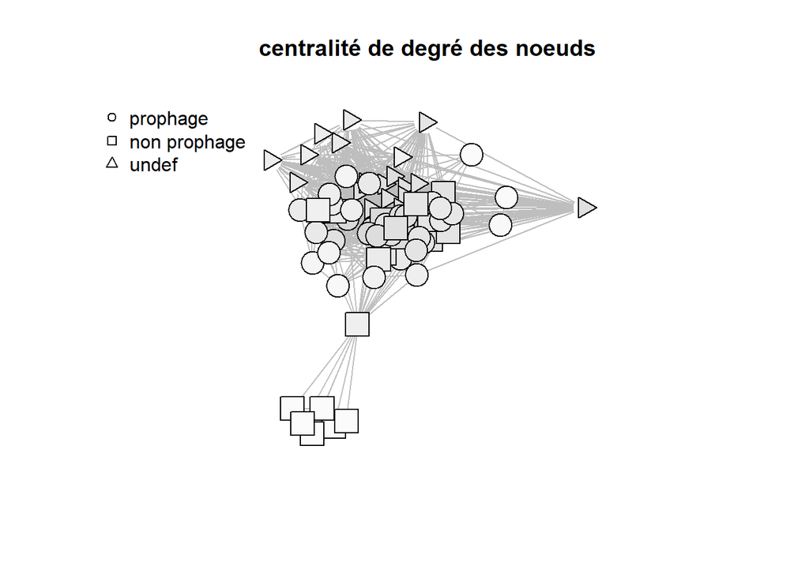

```r
graphCol2 = pal(fine)[as.numeric(degree(residGraph2),breaks = fine)]
graphCol3 = pal(fine)[as.numeric(closeness(residGraph2),breaks = fine)]

set.seed(1)
{plot(residGraph2,
     layout=l,
     edge.color="grey",
     #edge.width=Poids_Liens,
     vertex.color=graphCol2,
     vertex.label="",
     main = "centralité de degré des noeuds")
legend("topleft", legend=c("prophage","non prophage","undef"), pch=c(1,0,2), bty="n")}
```

[figure not shown]

```r
set.seed(1)
{plot(residGraph2,
     layout=l,
     edge.color="grey",
     #edge.width=Poids_Liens,
     vertex.color=graphCol3,
     vertex.label="",
     main = "centralité de proximité")
legend("topleft", legend=c("prophage","non prophage","undef"), pch=c(1,0,2), bty="n")}
```

II.2.10 Dessiner le même graphe en colorant les nœuds en fonction des ordres, familles ou genres de leurs hôtes (choisir le niveau taxonomique le plus adaptée, sachant que l’oeil ne peut pas discerner plus de 8-10 couleurs différentes sur un graphique)

#### Filtrer les éléments necessaires et observer

```r
#Les ordres présents dans :
Grp_virus%>%
  group_by(order)%>%
  distinct(order)
```

```
## # A tibble: 1 x 1
## # Groups:   order [1]
##   order
##   <chr>
## 1 Burkholderiales
```

```r
#Les familles (ce que l'on va choisir)
famillePresents <- Grp_virus%>%
  group_by(family)%>%
  distinct(family)

#Les genres
Grp_virus%>%
  group_by(genus)%>%
  distinct(genus)
```

```
## # A tibble: 19 x 1
## # Groups:   genus [19]
##    genus
##    <chr>
##  1 Delftia
##  2 Bordetella
##  3 Achromobacter
##  4 Alcaligenes
##  5 Caldimonas
##  6 Acidovorax
##  7 Hydrogenophaga
##  8 Pusillimonas
##  9 Brachymonas
## 10 Collimonas
## 11 Oxalobacter
## 12 Rhodoferax
## 13 Pelistega
## 14 Comamonas
## 15 Parasutterella
## 16 Herbaspirillum
## 17 Sutterella
## 18 Curvibacter
## 19 Janthinobacterium
```

#### Réseau dont les noeuds sont dessiné en fonction de leur famille d’appartenance

[figure not shown]

```r
V(residGraph2)$famille <- as.character(Grp_virus$family[match(V(residGraph2)$name,Grp_virus$Locus)])

colorsFamille <- c("blue","tomato", "gold", "dark green")
matriceDeCouleur <- matrix(colorsFamille, nrow=1, ncol=4)
colnames(matriceDeCouleur) <- famillePresents$family


for (FamCourant in V(residGraph2)$famille) {
  V(residGraph2)[V(residGraph2)$famille==FamCourant]$color <- matriceDeCouleur[,FamCourant]
}

set.seed(1)
{plot(residGraph2,
     layout=l,
     edge.color="grey",
     #edge.width=Poids_Liens,
     vertex.label="",
     vertex.shapes=V(residGraph2)$shape,
     vertex.color=V(residGraph2)$color,
     main = "Répartition des virus selon leur appartenance aux Familles des hôtes")
legend(x=-1.5, y=-1.1, unique(V(residGraph2)$famille), pch=21,col="#777777", pt.bg=colorsFamille, pt.cex=2, cex=0.8, bty="n", ncol=2)
legend("topleft", legend=c("prophage","non prophage","undef"), pch=c(1,0,2), bty="n")}
```

II.2.11

```r
components(residGraph2)
```

```
## $membership
## NC_013697  MF663786 NC_029075 NC_027348  KF787094 NC_028908 NC_023556  VI_01096
##         1         1         1         1         1         1         1         1
##  VI_05604 NC_029106  KY000219  KY000220  KY000218  KX961385  KY000221  VI_01114
##         1         1         1         1         1         1         1         1
##  VI_01077  VI_01098 NC_028768 NC_028834  VI_05578 NC_029033  VI_05545 NC_005357
##         1         1         1         1         1         1         1         1
##  VI_01099  VI_01106  VI_01111  VI_01093  VI_01081  VI_05726 NC_028702  VI_01115
##         1         1         1         1         1         1         1         1
##  VI_05579 NC_029061  VI_01069  VI_05731  VI_05733  VI_05582  VI_01082  VI_05620
##         1         1         1         1         1         1         1         1
##  VI_05548  VI_05605  VI_01071  VI_05580  VI_05588  VI_01073  VI_01117  VI_05734
##         1         1         1         1         1         1         1         1
##  VI_01100  VI_01076  VI_01092  VI_01097  VI_05590  VI_01080  VI_05589  VI_05737
##         1         1         1         1         1         1         1         1
##  VI_01116  VI_01118  VI_05729  VI_01072  VI_05735  VI_05727  VI_05730  VI_01107
##         1         1         1         1         1         1         1         1
##  VI_05581  VI_05603  VI_05736  VI_05732  VI_05728  VI_05546
##         1         1         1         1         1         1
##
## $csize
## [1] 70
##
## $no
## [1] 1
```

Il y’en à qu’une seul

II.2.12 Déterminer les communautés du graphe de deux façons : • en utilisant l’optmization multi-niveau (fonction cluster_louvain()) • en utilisant l’algorithme « edge betweenness (Newman-Girvan) »

#### cluster_louvain

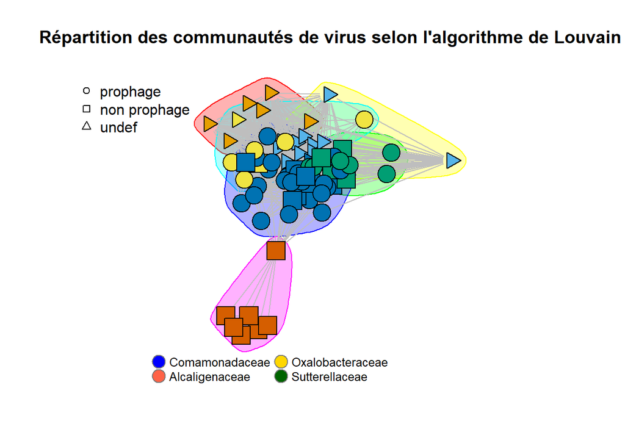

```r
CL <- cluster_louvain(residGraph2)

set.seed(1)
{plot(CL, residGraph2,
     layout=l,
     edge.color="grey",
     #edge.width=Poids_Liens,
     vertex.label="",
     vertex.color=V(residGraph2)$color,
     main = "Répartition des communautés de virus selon l'algorithme de Louvain")
legend(x=-1.5, y=-1.1, unique(V(residGraph2)$famille), pch=21,col="#777777", pt.bg=colorsFamille, pt.cex=2, cex=0.8, bty="n", ncol=2)
legend("topleft", legend=c("prophage","non prophage","undef"), pch=c(1,0,2), bty="n")}
```

#### Newman-Girvan

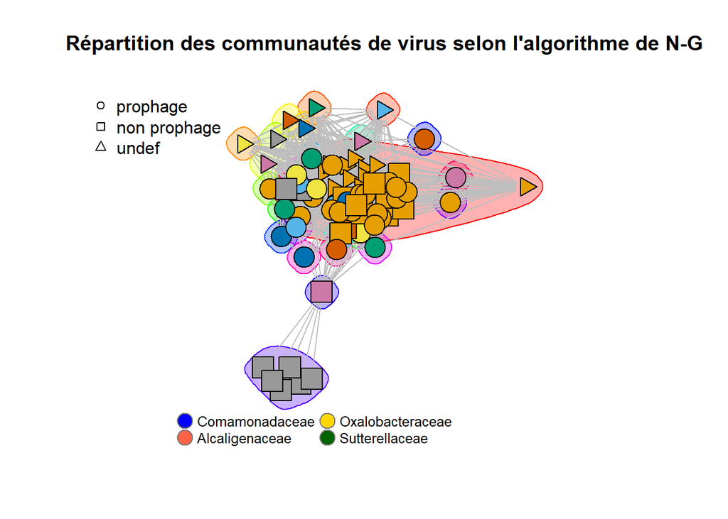

```r
ceb <- cluster_edge_betweenness(residGraph2, directed = F)

set.seed(1)
{plot(ceb, residGraph2,
     layout=l,
     edge.color="grey",
     #edge.width=Poids_Liens,
     vertex.label="",
     vertex.color=V(residGraph2)$color,
     main = "Répartition des communautés de virus selon l'algorithme de N-G")
legend(x=-1.5, y=-1.1, unique(V(residGraph2)$famille), pch=21,col="#777777", pt.bg=colorsFamille, pt.cex=2, cex=0.8, bty="n", ncol=2)
legend("topleft", legend=c("prophage","non prophage","undef"), pch=c(1,0,2), bty="n")}
```

#### Comparaison des deux communautés selon l’optmisation multi-niveau et l’algorithme de Newman-Girvan

II.2.13 comparer les structures de ces deux communautés : ◦ nombre de communautés détectées par les deux algorithmes ◦ taille de ces communautés ◦ chevauchement de ces communautés

```r
#nombre de communautés détectées par les deux algorithmes
length(CL)
```

```
## [1] 6
```

```r
length(ceb)
```

```
## [1] 32
```

```r
#taille de ces communautés
sizes(CL)
```

```
## Community sizes
##  1  2  3  4  5  6
##  6 11 10  7 29  7
```

```r
sizes(ceb)
```

```
## Community sizes
##  1  2  3  4  5  6  7  8  9 10 11 12 13 14 15 16 17 18 19 20 21 22 23 24 25 26
## 34  1  1  1  1  1  1  1  1  1  1  1  1  1  1  1  1  1  1  1  1  1  1  6  1  1
## 27 28 29 30 31 32
##  1  1  1  1  1  1
```

```r
modularity(CL)
```

```
## [1] 0.3871908
```

```r
modularity(ceb)
```

```
## [1] 0.1006834
```

```r
#chevauchement de ces communautés
compare(comm1 = CL, comm2 = ceb)
```

```
## [1] 1.908986
```

#### Dernier graphique (module colorié selon Louvain)

II.2.14 dessiner le graphe en utilisant la même disposition des nœuds que précédemment et en coloriant les nœuds de chaque module déterminé avec la méthode Louvain avec une couleur différente

[figure not shown]

```r
set.seed(1)
{plot(CL, residGraph2,
     layout=l,
     edge.color="grey",
     #edge.width=Poids_Liens,
     vertex.label="",
     vertex.color=membership(CL),
     main = "Représentaion du réseau de Famille des hôtes")
legend(x=-1.5, y=-1.1, unique(V(residGraph2)$famille), pch=21,col="#777777", pt.bg=colorsFamille, pt.cex=2, cex=0.8, bty="n", ncol=2)
legend("topleft", legend=c("prophage","non prophage","undef"), pch=c(1,0,2), bty="n")}
```